# Sewer Repair Data Analysis

Emma Furth

Data 269

Montgomery College

## Variable of Interest: Sewer Repair Alerts

[figure not shown]

Using alerts scraped from the WSSC website

Scraped from the [WSSC alerts archive](https://www.wsscwater.com/newsroom?type%5B253%5D=253) using [this utility](https://github.com/emmafurth/WSSCAlertsScraper)

[figure not shown]

## Aggregating data with H3 Hexes

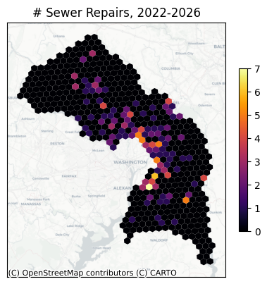

Will sum total number of repairs for every hex in PG/MC

Using resolution 7

Advantages:

- Discrete, uniform structure
- Easily indexed with x-y coordinates
- Enables easy joining of disparate spatial datasets

### Spatial Analysis Method 1: Global Spatial Autocorrelation

[figure not shown]

([Source](https://doc.esri.com/en/arcgis-pro/latest/tool-reference/spatial-statistics/spatial-autocorrelation.html?tabs=dialog))

Does the data cluster, or disperse?

### Important terms

**Z-score:** How much the variable in a given hex deviates from the mean

**Spatial Lag:** The average value of each hex and all its neighbors

**Global Moran's $I$:** A statistic that measures the tendency of spatial data to cluster or disperse

- Always between -1 and 1
- Closer to 1 -> tends to cluster
- Closer to -1 -> tends to disperse
- Closer to 0 -> tends towards randomness

(For more info read [here](https://geographicdata.science/book/notebooks/06_spatial_autocorrelation.html))

### Finding Global Moran's I

Because we're using H3 hexes, we can calculate Global Moran's $I$ with the following simplified formula:

$$ I = \frac{\sum_{i} z_i \cdot \sum_i w_ij \cdot z_j}{N} $$

(For more info see [here](https://github.com/uber/h3-py-notebooks/blob/master/notebooks/urban_analytics.ipynb))

### Hypotheses

$H_0$: The spatial distribution of sewer repair alerts is random

$H_a$: The spatial distribution is not random

### Results

```
I = 0.2729805843255545
```

```
P_sim = 0.001000
```

Conclusion: Can reject $H_0$.

$I$ is positive, but not high; weakly clustered

Bonus: Spatial lags can also make clusters more visually apparent

[figure not shown]

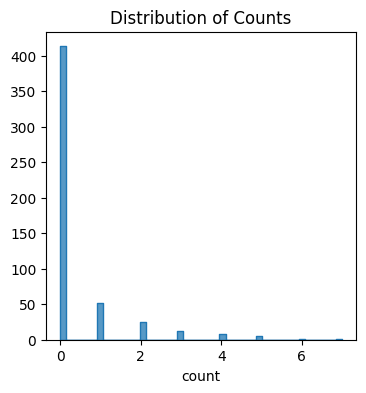

Distribution of the counts looks like Poisson distribution, therefore we'll be using Poisson regression

### Independent Variable 1: Traffic

[figure not shown]

**Name:** Annual Average Daily Traffic (AADT)

**Definition:** The number of vehicles expected to pass a given location on an average day of the year ([Source](https://www.roads.maryland.gov/OPPEN/Data_Dictionary.pdf))

**Data Source:** [Maryland Department of Transportation (MDOT)](https://data-maryland.opendata.arcgis.com/datasets/mdot-sha-annual-average-daily-traffic-aadt-locations/explore?location=38.843861%2C-77.269759%2C8)

**Reasoning:** High traffic -> More underground vibrartions -> potential damage to sewer pipes

### Independent Variable 2: Tree Canopy

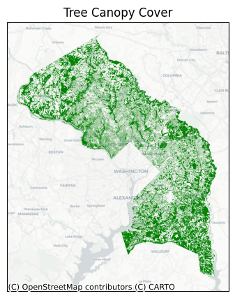

**Name:** Tree Canopy Cover

**Definition:** Set of polygons representing tree canopy in PG and Montgomery Counties.

**Data Source:** Combined similar datasets for [Prince George's](https://gisdata.pgplanning.org/opendata/search.asp?s=Tree_Canopy_2023_Py) and [Montgomery](https://data-mcplanning.hub.arcgis.com/datasets/0276692e49bb441c8bd0a823da2de121/about) Counties using qGIS. Both dataset appear to originate from the same LiDAR survey performed by Maryland-National Capital Park and Planning Commission (M-NCPPC).

**Reasoning:** More trees -> more tree roots potentially damaging pipes

### Aggregating Everything to H3

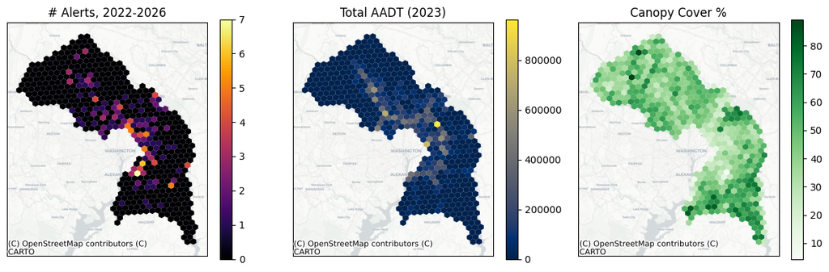

### Hypotheses

$H_0$: No correlation between canopy and traffic vs alerts

$H_1$: There is some correlation

Significance level: 0.05

### Results

Generalized Linear Model Regression Results

| Dep. Variable: | count | No. Observations: | 517 |
| --- | --- | --- | --- |
| Model: | GLM | Df Residuals: | 514 |
| Model Family: | Poisson | Df Model: | 2 |
| Link Function: | Log | Scale: | 1.0000 |
| Method: | IRLS | Log-Likelihood: | -461.45 |
| Date: | Thu, 14 May 2026 | Deviance: | 666.67 |
| Time: | 19:06:34 | Pearson chi2: | 1.12e+03 |
| No. Iterations: | 7 | Pseudo R-squ. (CS): | 0.1408 |
| Covariance Type: | nonrobust |  |  |

|  | coef | std err | z | P>\|z\| | [0.025 | 0.975] |
| --- | --- | --- | --- | --- | --- | --- |
| const | 0.0289 | 0.225 | 0.129 | 0.898 | -0.411 | 0.469 |
| canopy_pct | -0.0278 | 0.005 | -5.335 | 0.000 | -0.038 | -0.018 |
| AADT_2023 | 2.295e-06 | 3.57e-07 | 6.429 | 0.000 | 1.6e-06 | 2.99e-06 |

$p$ is less than 0.05 for both variables

We can reject $H_0$

## Conclusion

Statistically significant evidence for Spatial Autocorrelation (though relationship is weak)

Same for correlation with traffic & tree canopy

More research needed